# Exercise 14: Spatial statistics for spatial omics data

## Load some packages

```r
library(SpatialExperiment)
library(SingleCellExperiment)
library(ExperimentHub)
library(ggspavis)
library(spatstat)
library(dplyr)
library(ggplot2)
library(imcdatasets)
```

## Question 1. Create synthetic spatial point patterns and explore K functions.

Consider the following 4 spatial point patterns:

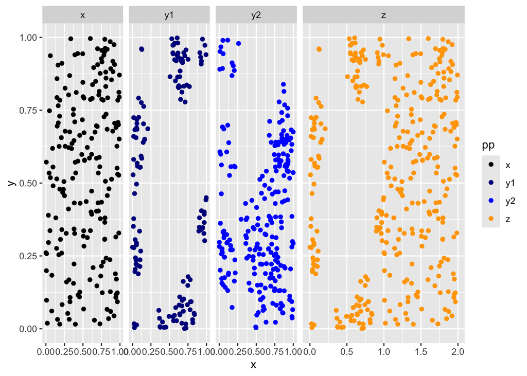

```r
set.seed(12345)

# completely random process
x <- rpoint(200)

nclust <- function(x0, y0, radius, n)
  runifdisc(n, radius, centre=c(x0, y0))

# clustered process
y1 <- rPoissonCluster(12.5, 0.5, nclust, radius=0.1, n=16)
y2 <- rPoissonCluster(12.5, 0.5, nclust, radius=0.15, n=16)


x_df <- as.data.frame(x)
y1_df <- as.data.frame(y1)

# hacky construction of a mixed point process
x_df_star <- cbind(x=x$x+1, y=x$y)
z_df <- rbind(x_df_star, y1_df)
z <- as.ppp(z_df, c(0,2,0,1))

# make a list of point patterns and plot them
pps <- list(x=x, y1=y1, y2=y2, z=z)

dfs <- mapply(function(u,v) {
  cbind(as.data.frame(u), pp=v)
}, pps, names(pps), SIMPLIFY = FALSE) %>% bind_rows()

cols <- c("x" = "black",
          "y1" = "blue4",
          "y2" = "blue",
          "z" = "orange")

ggplot(dfs, aes(x,y, colour=pp)) +
  geom_point() +
  facet_grid(~pp, scales = "free_x", space = "free_x") +
  scale_colour_manual(values = cols)
```

Calculate Ripley’s K function (e.g., `Kinhom`, among many choices in the `spatstat` package) for each of the 4 point processes above and overlay them in a single plot (with different colour or line type for each). Comment on the plot (e.g., is the most-clustered point process where you would expect it, relative to the completely spatially random process?).

## Question 2. Using the [Damond et al. 2019](https://www.sciencedirect.com/science/article/pii/S1550413118306910) dataset to create spatial stats summaries and low-dimensional projections.

The following code pulls a small subset of the Damond et al. 2019 dataset:

```r
eh <- ExperimentHub::ExperimentHub()
ttl <- "Damond_2019_Pancreas - sce - v1"

oid <- eh[eh$title == ttl]$ah_id
sce <- eh[[oid]]
```

```
see ?imcdatasets and browseVignettes('imcdatasets') for documentation
```

```
loading from cache
```

```r
(spe <- toSpatialExperiment(sce, sample_id = "image_name",
                           spatialCoordsNames = c("cell_x", "cell_y")))
```

```
class: SpatialExperiment
dim: 38 252059
metadata(0):
assays(3): counts exprs quant_norm
rownames(38): H3 SMA ... DNA1 DNA2
rowData names(6): channel metal ... antibody_clone full_name
colnames(252059): 138_1 138_2 ... 319_1149 319_1150
colData names(27): cell_id image_name ... patient_BMI sample_id
reducedDimNames(0):
mainExpName: Damond_2019_Pancreas_v1
altExpNames(0):
spatialCoords names(2) : cell_x cell_y
imgData names(0):
```

```r
table(spe$patient_stage, spe$patient_id)
```

```
                 6126  6180  6414
  Long-duration     0 76880     0
  Non-diabetic  76766     0     0
  Onset             0     0 98413
```

```r
table(spe$image_name) %>% head(10)
```

```
 E02  E03  E04  E05  E06  E07  E08  E09  E10  E11
2785 3824 3139 1489 2362 2673 2959 3701 2647 1531
```

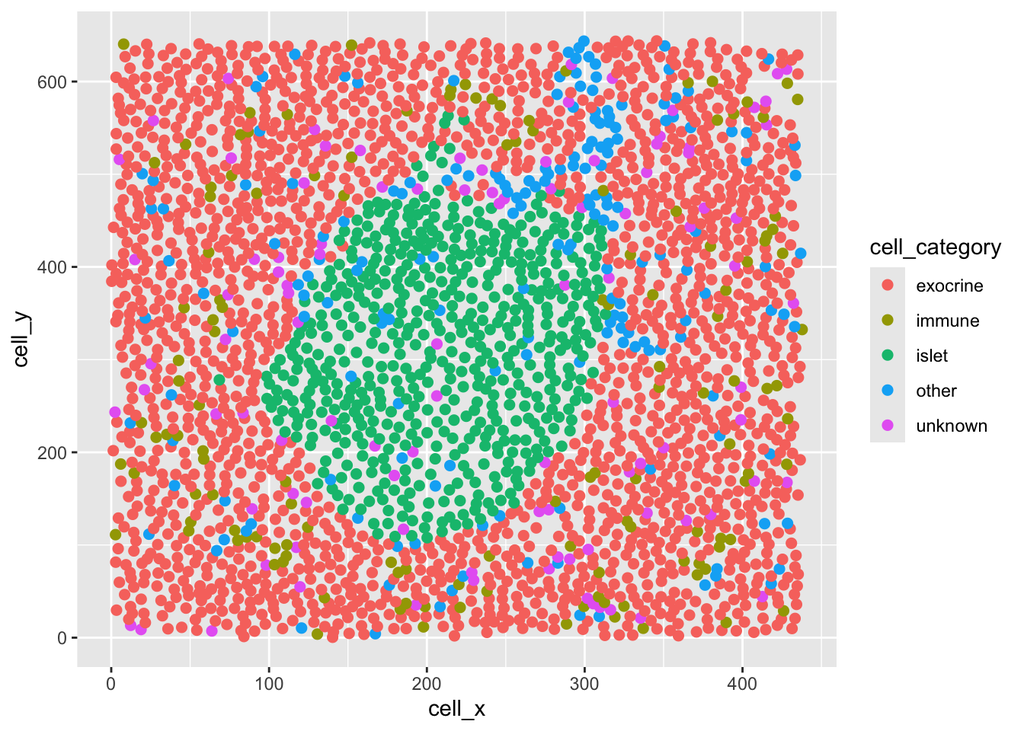

```r
df <- data.frame(spatialCoords(spe),
                 cell_type = spe$cell_type,
                 cell_category = spe$cell_category,
                 image_name = spe$image_name)

ggplot(df %>% filter(image_name == "E02"),
       aes(cell_x, cell_y, colour=cell_category)) +
  geom_point(size = 2)
```

Take some time to understand what you have in this `SpatialExperiment` object. In particular, the Damond dataset has multiple biopsies/images from each patient. Make some spatial plots of annotated cells in 2-3 images using colour for either `cell_type` or `cell_category`. What cells are generally within the islet category?

The next task is to reduce each image to a curve and from the set of curves, perform *functional PCA* to understand the overall similarity of disease states. That is, you have multiple images for each patient and you should be able to, via fPCA, reduce each to a single point in a 2D plot. An example is shown [here](https://bioconductor.org/packages/release/bioc/vignettes/spatialFDA/inst/doc/DiabetesIsletExample.html#functional-principal-component-analysis). As done in the example, it is recommended to calculate the Gcross function between alpha and Tc cells. Comment on your fPCA plot.